# Linear Regression - My Practice

Class work and practice at home

Personal practice

18 November 2026

# 1 About this practice

I am using this file to practise linear regression in R. I used a small sample dataset to understand simple regression, multiple regression, prediction and diagnostic plots.

The data in this exercise is created for practice. It is not real student data.

# 2 1. Packages

I use `ggplot2` for graphs. Most of the regression functions are already available in base R.

```r
if (!"ggplot2" %in% rownames(installed.packages())) {
  install.packages("ggplot2")
}
library(ggplot2)
```

# 3 2. Prepare the practice data

`Marks` is the outcome I want to explain. `Study_Hours` and `Attendance` are possible predictors.

```r
regression_data <- data.frame(
  Student = paste0("Student", 1:12),
  Study_Hours = c(1, 2, 2.5, 3, 4, 4.5, 5, 6, 6.5, 7, 8, 9),
  Attendance = c(55, 60, 62, 65, 70, 72, 75, 80, 82, 85, 90, 95),
  Marks = c(42, 46, 50, 53, 58, 63, 65, 70, 74, 77, 83, 90)
)

regression_data
```

| Student | Study_Hours | Attendance | Marks |
| --- | --- | --- | --- |
| Student1 | 1.0 | 55 | 42 |
| Student2 | 2.0 | 60 | 46 |
| Student3 | 2.5 | 62 | 50 |
| Student4 | 3.0 | 65 | 53 |
| Student5 | 4.0 | 70 | 58 |
| Student6 | 4.5 | 72 | 63 |
| Student7 | 5.0 | 75 | 65 |
| Student8 | 6.0 | 80 | 70 |
| Student9 | 6.5 | 82 | 74 |
| Student10 | 7.0 | 85 | 77 |

[output cut: 2 more lines]

```r
head(regression_data)
```

|  | Student | Study_Hours | Attendance | Marks |
| --- | --- | --- | --- | --- |
| 1 | Student1 | 1.0 | 55 | 42 |
| 2 | Student2 | 2.0 | 60 | 46 |
| 3 | Student3 | 2.5 | 62 | 50 |
| 4 | Student4 | 3.0 | 65 | 53 |
| 5 | Student5 | 4.0 | 70 | 58 |
| 6 | Student6 | 4.5 | 72 | 63 |

```r
str(regression_data)
```

```
#> 'data.frame':    12 obs. of  4 variables:
#>  $ Student    : chr  "Student1" "Student2" "Student3" "Student4" ...
#>  $ Study_Hours: num  1 2 2.5 3 4 4.5 5 6 6.5 7 ...
#>  $ Attendance : num  55 60 62 65 70 72 75 80 82 85 ...
#>  $ Marks      : num  42 46 50 53 58 63 65 70 74 77 ...
```

```r
summary(regression_data)
```

```
#>       Student    Study_Hours      Attendance        Marks
#>  Length   :12   Min.   :1.000   Min.   :55.00   Min.   :42.00
#>  N.unique :12   1st Qu.:2.875   1st Qu.:64.25   1st Qu.:52.25
#>  N.blank  : 0   Median :4.750   Median :73.50   Median :64.00
#>  Min.nchar: 8   Mean   :4.875   Mean   :74.25   Mean   :64.25
#>  Max.nchar: 9   3rd Qu.:6.625   3rd Qu.:82.75   3rd Qu.:74.75
#>                 Max.   :9.000   Max.   :95.00   Max.   :90.00
```

```r
# Check missing values in each column.
colSums(is.na(regression_data))
```

```
#>     Student Study_Hours  Attendance       Marks
#>           0           0           0           0
```

# 4 3. Explore the variables

I check the distributions and relationships before fitting a model.

```r
summary(regression_data[c("Study_Hours", "Attendance", "Marks")])
```

```
#>   Study_Hours      Attendance        Marks
#>  Min.   :1.000   Min.   :55.00   Min.   :42.00
#>  1st Qu.:2.875   1st Qu.:64.25   1st Qu.:52.25
#>  Median :4.750   Median :73.50   Median :64.00
#>  Mean   :4.875   Mean   :74.25   Mean   :64.25
#>  3rd Qu.:6.625   3rd Qu.:82.75   3rd Qu.:74.75
#>  Max.   :9.000   Max.   :95.00   Max.   :90.00
```

## 4.1 3.1 Study hours and marks

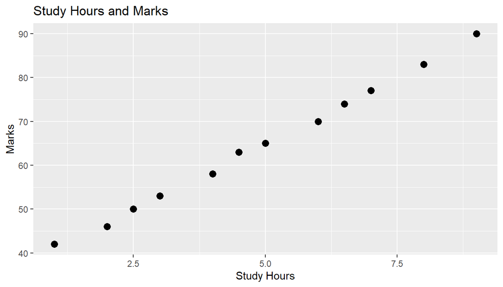

```r
ggplot(regression_data, aes(x = Study_Hours, y = Marks)) +
  geom_point(size = 3) +
  labs(
    title = "Study Hours and Marks",
    x = "Study Hours",
    y = "Marks"
  )
```

## 4.2 3.2 Attendance and marks

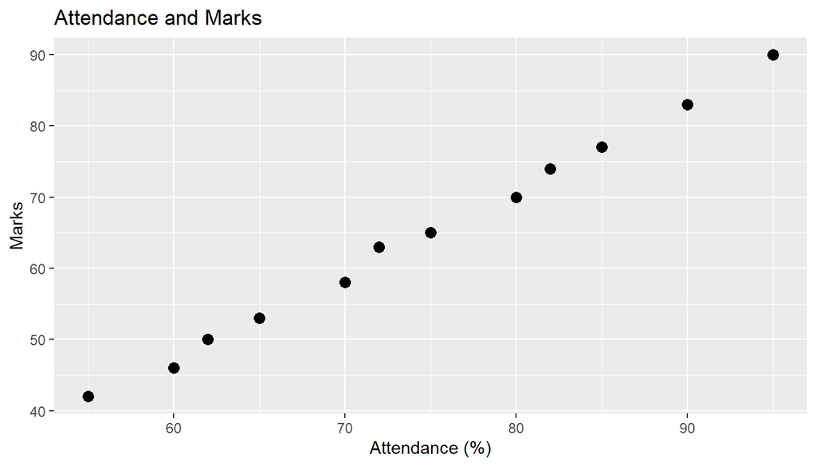

```r
ggplot(regression_data, aes(x = Attendance, y = Marks)) +
  geom_point(size = 3) +
  labs(
    title = "Attendance and Marks",
    x = "Attendance (%)",
    y = "Marks"
  )
```

# 5 4. Correlation

Correlation measures the direction and strength of a linear relationship between two numeric variables. It ranges from -1 to +1.

- Positive correlation: the variables tend to increase together.
- Negative correlation: one tends to decrease as the other increases.
- Correlation near zero: little linear association.

Correlation does not prove that one variable causes another.

```r
cor(
  regression_data$Study_Hours,
  regression_data$Marks,
  method = "pearson"
)
```

```
#> [1] 0.9988195
```

```r
# Correlations among all numeric variables.
cor(regression_data[c("Study_Hours", "Attendance", "Marks")])
```

```
#>             Study_Hours Attendance     Marks
#> Study_Hours   1.0000000  0.9998378 0.9988195
#> Attendance    0.9998378  1.0000000 0.9984068
#> Marks         0.9988195  0.9984068 1.0000000
```

# 6 5. Simple linear regression

Simple linear regression uses one predictor. Here I predict Marks using Study_Hours.

The formula `Marks ~ Study_Hours` means:

- `Marks` is the response variable (Y).
- `Study_Hours` is the predictor variable (X).

```r
simple_model <- lm(
  Marks ~ Study_Hours,
  data = regression_data
)

summary(simple_model)
```

```
#>
#> Call:
#> lm(formula = Marks ~ Study_Hours, data = regression_data)
#>
#> Residuals:
#>      Min       1Q   Median       3Q      Max
#> -1.04102 -0.30925 -0.03191  0.27735  1.14129
#>
#> Coefficients:
#>             Estimate Std. Error t value Pr(>|t|)
#> (Intercept) 34.82224    0.50404   69.09 9.84e-15 ***
#> Study_Hours  6.03646    0.09283   65.02 1.80e-14 ***
#> ---
#> Signif. codes:  0 '***' 0.001 '**' 0.01 '*' 0.05 '.' 0.1 ' ' 1
#>
#> Residual standard error: 0.7687 on 10 degrees of freedom
#> Multiple R-squared:  0.9976, Adjusted R-squared:  0.9974
#> F-statistic:  4228 on 1 and 10 DF,  p-value: 1.802e-14
```

## 6.1 5.1 Understanding the coefficients

The intercept is the estimated mark when study hours are zero. The slope estimates the change in marks for one additional study hour, according to this model.

```r
coef(simple_model)
```

```
#> (Intercept) Study_Hours
#>   34.822242    6.036463
```

I also check the fitted values and residuals. A residual is the observed value minus the fitted value.

```r
regression_data$Fitted_Marks <- fitted(simple_model)
regression_data$Residuals <- residuals(simple_model)

regression_data[, c("Student", "Marks", "Fitted_Marks", "Residuals")]
```

| Student | Marks | Fitted_Marks | Residuals |
| --- | --- | --- | --- |
| Student1 | 42 | 40.85871 | 1.141294439 |
| Student2 | 46 | 46.89517 | -0.895168642 |
| Student3 | 50 | 49.91340 | 0.086599818 |
| Student4 | 53 | 52.93163 | 0.068368277 |
| Student5 | 58 | 58.96809 | -0.968094804 |
| Student6 | 63 | 61.98633 | 1.013673655 |
| Student7 | 65 | 65.00456 | -0.004557885 |
| Student8 | 70 | 71.04102 | -1.041020966 |
| Student9 | 74 | 74.05925 | -0.059252507 |
| Student10 | 77 | 77.07748 | -0.077484047 |

[output cut: 2 more lines]

## 6.2 5.2 Regression graph

The points show the observed marks. The line is the fitted linear relationship.

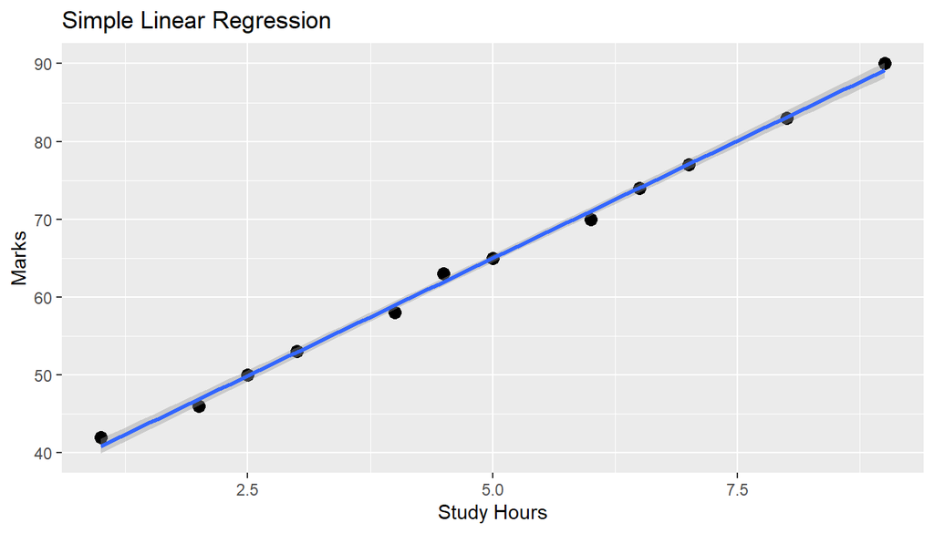

```r
ggplot(regression_data, aes(x = Study_Hours, y = Marks)) +
  geom_point(size = 3) +
  geom_smooth(method = "lm", se = TRUE) +
  labs(
    title = "Simple Linear Regression",
    x = "Study Hours",
    y = "Marks"
  )
```

# 7 6. Making predictions

I use `predict()` to estimate marks for new study-hour values. The new data must use the same predictor name as the model.

```r
new_students <- data.frame(
  Study_Hours = c(3, 5, 7, 8)
)

predicted_marks <- predict(
  simple_model,
  newdata = new_students
)

data.frame(
  Study_Hours = new_students$Study_Hours,
  Predicted_Marks = as.numeric(predicted_marks)
)
```

| Study_Hours | Predicted_Marks |
| --- | --- |
| 3 | 52.93163 |
| 5 | 65.00456 |
| 7 | 77.07748 |
| 8 | 83.11395 |

I can request a confidence interval for the estimated mean response.

```r
predict(
  simple_model,
  newdata = new_students,
  interval = "confidence"
)
```

```
#>        fit      lwr      upr
#> 1 52.93163 52.30324 53.56002
#> 2 65.00456 64.50945 65.49966
#> 3 77.07748 76.41592 77.73905
#> 4 83.11395 82.30014 83.92776
```

A prediction interval is wider because it estimates a range for an individual future observation.

```r
predict(
  simple_model,
  newdata = new_students,
  interval = "prediction"
)
```

```
#>        fit      lwr      upr
#> 1 52.93163 51.10725 54.75602
#> 2 65.00456 63.22169 66.78743
#> 3 77.07748 75.24141 78.91356
#> 4 83.11395 81.21769 85.01021
```

# 8 7. Multiple linear regression

Multiple regression uses two or more predictors. Here I use Study_Hours and Attendance to predict Marks.

```r
multiple_model <- lm(
  Marks ~ Study_Hours + Attendance,
  data = regression_data
)

summary(multiple_model)
```

```
#>
#> Call:
#> lm(formula = Marks ~ Study_Hours + Attendance, data = regression_data)
#>
#> Residuals:
#>      Min       1Q   Median       3Q      Max
#> -0.93301 -0.50531  0.00082  0.31618  1.28758
#>
#> Coefficients:
#>             Estimate Std. Error t value Pr(>|t|)
#> (Intercept)   81.319     51.795   1.570   0.1509
#> Study_Hours   10.709      5.206   2.057   0.0698 .
#> Attendance    -0.933      1.039  -0.898   0.3927
#> ---
#> Signif. codes:  0 '***' 0.001 '**' 0.01 '*' 0.05 '.' 0.1 ' ' 1
#>
#> Residual standard error: 0.7763 on 9 degrees of freedom
#> Multiple R-squared:  0.9978, Adjusted R-squared:  0.9974
#> F-statistic:  2073 on 2 and 9 DF,  p-value: 1.024e-12
```

```r
coef(multiple_model)
```

```
#> (Intercept) Study_Hours  Attendance
#>  81.3186275  10.7091503  -0.9330065
```

I compare the R-squared values, but I do not choose a model using R-squared alone. I also need to consider assumptions, data quality, adjusted R-squared and the purpose of the analysis.

```r
simple_summary <- summary(simple_model)
multiple_summary <- summary(multiple_model)

data.frame(
  Model = c("Simple regression", "Multiple regression"),
  R_Squared = c(
    simple_summary$r.squared,
    multiple_summary$r.squared
  ),
  Adjusted_R_Squared = c(
    simple_summary$adj.r.squared,
    multiple_summary$adj.r.squared
  ),
  Residual_Standard_Error = c(
    simple_summary$sigma,
    multiple_summary$sigma
  )
)
```

| Model | R_Squared | Adjusted_R_Squared | Residual_Standard_Error |
| --- | --- | --- | --- |
| Simple regression | 0.9976405 | 0.9974045 | 0.7686899 |
| Multiple regression | 0.9978344 | 0.9973532 | 0.7762590 |

# 9 8. Prediction with multiple regression

For multiple regression, the new data must include all predictors used in the model.

```r
new_data_multiple <- data.frame(
  Study_Hours = c(4, 6, 8),
  Attendance = c(70, 80, 90)
)

multiple_predictions <- predict(
  multiple_model,
  newdata = new_data_multiple
)

data.frame(
  new_data_multiple,
  Predicted_Marks = as.numeric(multiple_predictions)
)
```

| Study_Hours | Attendance | Predicted_Marks |
| --- | --- | --- |
| 4 | 70 | 58.84477 |
| 6 | 80 | 70.93301 |
| 8 | 90 | 83.02124 |

# 10 9. Main linear regression assumptions

These are the four main assumptions I am reviewing.

1. **Linearity:** the relationship between predictors and response should be reasonably linear.
2. **Independence:** observations/errors should be independent. This depends on how the data was collected and ordered.
3. **Homoscedasticity:** residuals should have roughly constant variance across fitted values.
4. **Normality of residuals:** residuals should be approximately normally distributed for standard small-sample inference.

Diagnostic plots help me look for warning signs. They do not prove that an assumption is satisfied.

# 11 10. Diagnostic plots

The four standard diagnostic plots from `plot(lm_model)` are:

1. **Residuals vs Fitted:** checks linearity and whether residual spread is roughly constant.
2. **Normal Q-Q:** checks whether residuals are approximately normal.
3. **Scale-Location:** another check of constant residual spread.
4. **Residuals vs Leverage:** helps identify observations that may have strong influence.

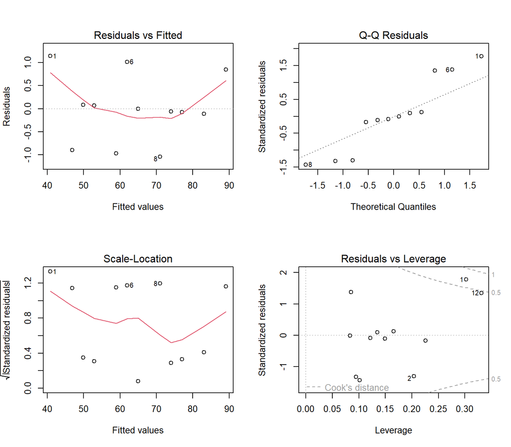

```r
par(mfrow = c(2, 2))
plot(simple_model)
```

```r
par(mfrow = c(1, 1))
```

These plots do not prove independence. I also need to consider how the observations were collected.

# 12 11. Checking residual normality

I use a histogram and Q-Q plot to inspect the residual distribution.

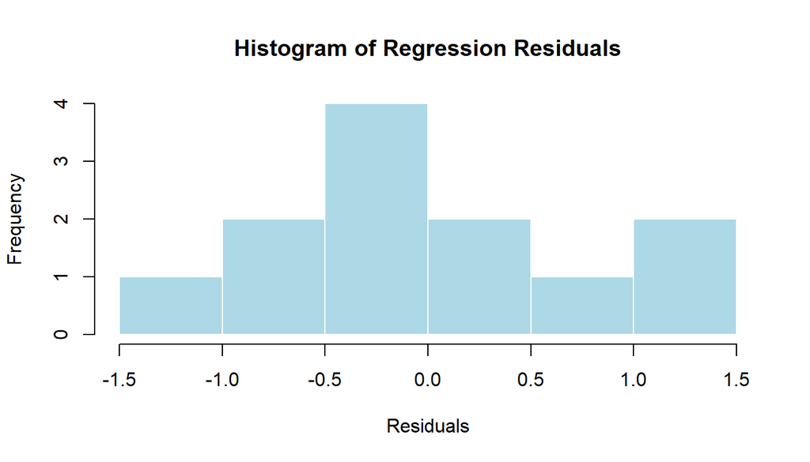

```r
model_residuals <- residuals(simple_model)

hist(
  model_residuals,
  main = "Histogram of Regression Residuals",
  xlab = "Residuals",
  col = "lightblue",
  border = "white"
)
```

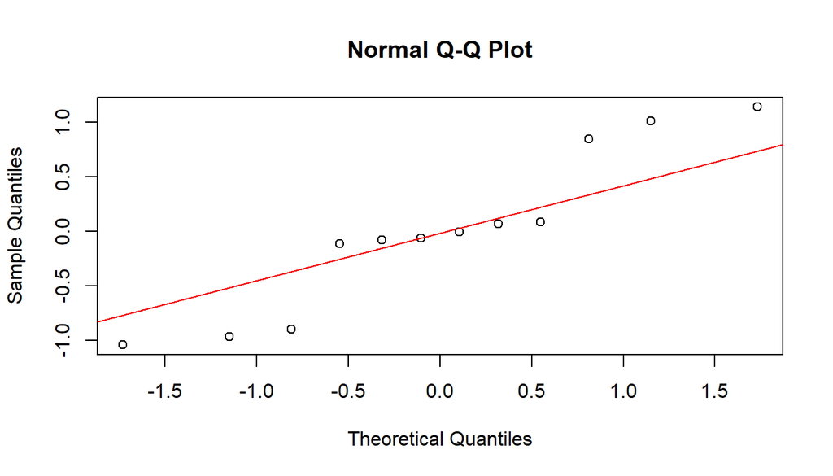

```r
qqnorm(model_residuals)
qqline(model_residuals, col = "red")
```

I can also run the Shapiro-Wilk test. Its null hypothesis is that the data are consistent with a normal distribution. I interpret the p-value together with the Q-Q plot, not by itself.

```r
shapiro.test(model_residuals)
```

```
#>
#>  Shapiro-Wilk normality test
#>
#> data:  model_residuals
#> W = 0.90306, p-value = 0.1737
```

# 13 12. Checking constant variance

I plot residuals against fitted values. I look for a roughly even vertical spread around zero.

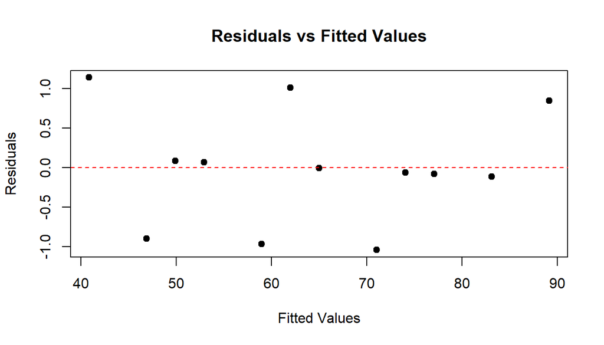

```r
plot(
  fitted(simple_model),
  residuals(simple_model),
  main = "Residuals vs Fitted Values",
  xlab = "Fitted Values",
  ylab = "Residuals",
  pch = 19
)
abline(h = 0, lty = 2, col = "red")
```

# 14 13. Checking influential observations

Cook’s distance helps identify observations that may strongly influence the fitted model. The reference line below is only a screening guide, not an automatic rule for deleting observations.

```r
cook_values <- cooks.distance(simple_model)
cook_values
```

```
#>            1            2            3            4            5            6
#> 6.846525e-01 2.181349e-01 1.509471e-03 7.109327e-04 9.140272e-02 8.874934e-02
#>            7            8            9           10           11           12
#> 1.749010e-06 1.157045e-01 4.694157e-04 1.047094e-03 4.138017e-03 4.530994e-01
```

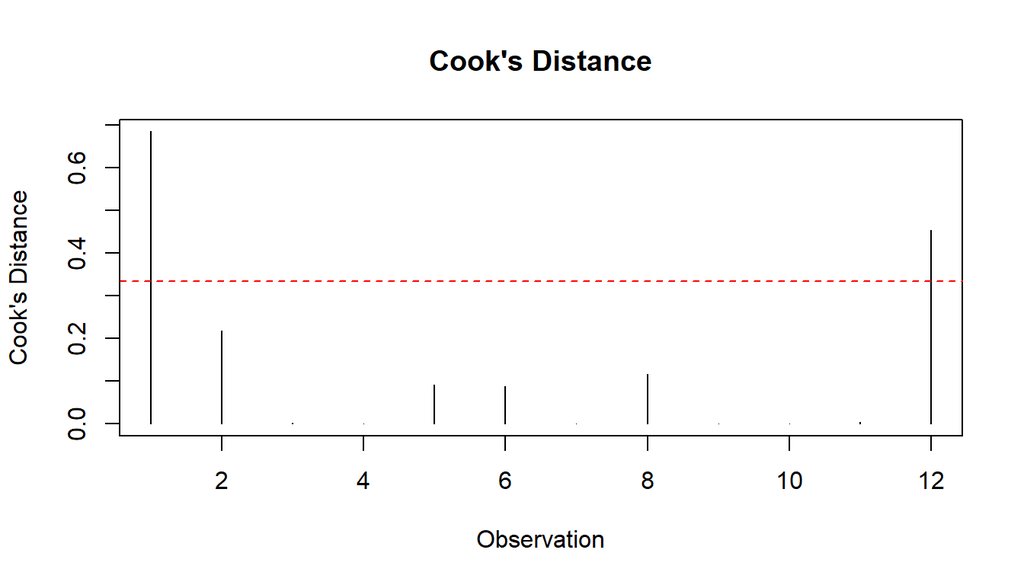

```r
plot(
  cook_values,
  type = "h",
  main = "Cook's Distance",
  xlab = "Observation",
  ylab = "Cook's Distance"
)

abline(
  h = 4 / nrow(regression_data),
  lty = 2,
  col = "red"
)
```

# 15 14. Practice questions

I will try these questions after reviewing the examples.

1. Fit a simple model using Attendance to predict Marks.
2. Explain the intercept and slope from the simple model.
3. Use `predict()` to estimate marks for 5 study hours.
4. Fit a multiple regression model using Study_Hours and Attendance.
5. Explain R-squared and adjusted R-squared.
6. What is the difference between a confidence interval and a prediction interval?
7. Use `plot(simple_model)` and explain the four plots.
8. What pattern in Residuals vs Fitted may suggest non-linearity or unequal variance?
9. Why does correlation not prove causation?
10. Explain why I should not automatically remove an observation just because Cook’s distance is high.

# 16 My short summary

- Simple linear regression uses one predictor.
- Multiple linear regression uses two or more predictors.
- `lm()` fits a linear regression model.
- `summary()` displays the model results.
- `coef()` extracts the estimated coefficients.
- `predict()` makes predictions for new data.
- Residuals are observed values minus fitted values.
- Diagnostic plots help me check regression assumptions.